# U.S. Election Outcome Prediction

Julia Yang

2026-01

## 1 Clean election data

### 1.1 Load and check

#### 1.1.1

```r
library(tidyverse)
election <- read_delim("data/us-elections_2000-2024.csv.bz2")
dim(election)
```

```
## [1] 43602    24
```

```r
election %>%
  sample_n(5)
```

```
## # A tibble: 5 × 24
##    FIPS  year state    state2 county       candidate party candidatevotes income
##   <dbl> <dbl> <chr>    <chr>  <chr>        <chr>     <chr>          <dbl>  <dbl>
## 1 48435  2000 Texas    TX     Sutton       George W… repu…           1063  22393
## 2 23015  2000 Maine    ME     Lincoln      Al Gore   demo…           8634  28493
## 3  4009  2012 Arizona  AZ     Graham       Barack O… demo…           3609  26585
## 4 40137  2024 Oklahoma OK     Stephens Co… Kamala H… demo…           3236     NA
## 5 56003  2016 Wyoming  WY     Big Horn     Donald T… repu…           4067  35845
## # ℹ 15 more variables: population <dbl>, LND010200D <dbl>, EDU695209D <dbl>,
## #   EDU600209D <dbl>, POP010210D <dbl>, POP220210D <dbl>, POP250210D <dbl>,
## #   POP320210D <dbl>, POP400210D <dbl>, POPESTIMATE <dbl>, BIRTHS <dbl>,
## #   DEATHS <dbl>, DOMESTICMIG <dbl>, INTERNATIONALMIG <dbl>, region <chr>
```

#### 1.1.2

A row represents the result of one party in one county in a year.

### 1.2 Fill missings

#### 1.2.1

```r
election %>%
  select(FIPS, county, year, income) %>%
  slice(7293:7312)
```

```
## # A tibble: 20 × 4
##     FIPS county        year income
##    <dbl> <chr>        <dbl>  <dbl>
##  1 15007 Kauai         2016  42689
##  2 15007 Kauai         2016  42689
##  3 15007 Kauai County  2020  52982
##  4 15007 Kauai County  2020  52982
##  5 15007 Kauai County  2024     NA
##  6 15007 Kauai County  2024     NA
##  7 15009 Maui          2000     NA
##  8 15009 Maui          2000     NA
##  9 15009 Maui          2004     NA
## 10 15009 Maui          2004     NA
## 11 15009 Maui          2008     NA
## 12 15009 Maui          2008     NA
## 13 15009 Maui          2012     NA
## 14 15009 Maui          2012     NA
## 15 15009 Maui          2016     NA
## 16 15009 Maui          2016     NA
## 17 15009 Maui County   2020     NA
## 18 15009 Maui County   2020     NA
## 19 15009 Maui County   2024     NA
## 20 15009 Maui County   2024     NA
```

#### 1.2.2

##### a)

```r
election %>%
  arrange(FIPS, year) %>%
  group_by(FIPS) %>%
  tidyr::fill(income, .direction = "downup") %>%
  ungroup() %>%
  filter((county == "Kauai County" & year == 2024) | (county == "Maui County" & year == 2000)) %>%
  select(FIPS, county, year, income)
```

```
## # A tibble: 2 × 4
##    FIPS county        year income
##   <dbl> <chr>        <dbl>  <dbl>
## 1 15007 Kauai County  2024  52982
## 2 15007 Kauai County  2024  52982
```

##### b)

- The missing income values are filled from the same county using the value adjacent years where income is observed.
- Income is not averaged.

##### c)

//use most recent values

```r
election %>%
  arrange(FIPS, year) %>%
  group_by(FIPS) %>%
  fill(income, .direction = "down") %>%
  ungroup()
```

```
## # A tibble: 43,602 × 24
##     FIPS  year state   state2 county  candidate      party candidatevotes income
##    <dbl> <dbl> <chr>   <chr>  <chr>   <chr>          <chr>          <dbl>  <dbl>
##  1  1001  2000 Alabama AL     Autauga Al Gore        demo…           4942  23584
##  2  1001  2000 Alabama AL     Autauga George W. Bush repu…          11993  23584
##  3  1001  2004 Alabama AL     Autauga John Kerry     demo…           4758  27745
##  4  1001  2004 Alabama AL     Autauga George W. Bush repu…          15196  27745
##  5  1001  2008 Alabama AL     Autauga Barack Obama   demo…           6093  33245
##  6  1001  2008 Alabama AL     Autauga John McCain    repu…          17403  33245
##  7  1001  2012 Alabama AL     Autauga Barack Obama   demo…           6363  35161
##  8  1001  2012 Alabama AL     Autauga Mitt Romney    repu…          17379  35161
##  9  1001  2016 Alabama AL     Autauga Hillary Clint… demo…           5936  39022
## 10  1001  2016 Alabama AL     Autauga Donald Trump   repu…          18172  39022
## # ℹ 43,592 more rows
## # ℹ 15 more variables: population <dbl>, LND010200D <dbl>, EDU695209D <dbl>,
## #   EDU600209D <dbl>, POP010210D <dbl>, POP220210D <dbl>, POP250210D <dbl>,
## #   POP320210D <dbl>, POP400210D <dbl>, POPESTIMATE <dbl>, BIRTHS <dbl>,
## #   DEATHS <dbl>, DOMESTICMIG <dbl>, INTERNATIONALMIG <dbl>, region <chr>
```

##### d)

group_by() should be use before fill(), and fill() operates wihtin each group, hence, it won’t fill in data from another county.

##### e)

The printout reveals that county is not a safe unique key because county name could be repetitive across states. Hence, FIPS is used to indentify each geographic units and this is why grouping and filling by FIPS is more reliable.

#### 1.2.3

```r
election_fill <- election %>%
  arrange(FIPS, year) %>%
  group_by(FIPS) %>%
  tidyr::fill("income", "population", .direction = "downup") %>%
  ungroup()
election_fill
```

```
## # A tibble: 43,602 × 24
##     FIPS  year state   state2 county  candidate      party candidatevotes income
##    <dbl> <dbl> <chr>   <chr>  <chr>   <chr>          <chr>          <dbl>  <dbl>
##  1  1001  2000 Alabama AL     Autauga Al Gore        demo…           4942  23584
##  2  1001  2000 Alabama AL     Autauga George W. Bush repu…          11993  23584
##  3  1001  2004 Alabama AL     Autauga John Kerry     demo…           4758  27745
##  4  1001  2004 Alabama AL     Autauga George W. Bush repu…          15196  27745
##  5  1001  2008 Alabama AL     Autauga Barack Obama   demo…           6093  33245
##  6  1001  2008 Alabama AL     Autauga John McCain    repu…          17403  33245
##  7  1001  2012 Alabama AL     Autauga Barack Obama   demo…           6363  35161
##  8  1001  2012 Alabama AL     Autauga Mitt Romney    repu…          17379  35161
##  9  1001  2016 Alabama AL     Autauga Hillary Clint… demo…           5936  39022
## 10  1001  2016 Alabama AL     Autauga Donald Trump   repu…          18172  39022
## # ℹ 43,592 more rows
## # ℹ 15 more variables: population <dbl>, LND010200D <dbl>, EDU695209D <dbl>,
## #   EDU600209D <dbl>, POP010210D <dbl>, POP220210D <dbl>, POP250210D <dbl>,
## #   POP320210D <dbl>, POP400210D <dbl>, POPESTIMATE <dbl>, BIRTHS <dbl>,
## #   DEATHS <dbl>, DOMESTICMIG <dbl>, INTERNATIONALMIG <dbl>, region <chr>
```

#### 1.2.4

```r
election_fill %>%
  select(FIPS, county, year, income) %>%
  slice(7293:7312)
```

```
## # A tibble: 20 × 4
##     FIPS county        year income
##    <dbl> <chr>        <dbl>  <dbl>
##  1 15007 Kauai         2016  42689
##  2 15007 Kauai         2016  42689
##  3 15007 Kauai County  2020  52982
##  4 15007 Kauai County  2020  52982
##  5 15007 Kauai County  2024  52982
##  6 15007 Kauai County  2024  52982
##  7 15009 Maui          2000     NA
##  8 15009 Maui          2000     NA
##  9 15009 Maui          2004     NA
## 10 15009 Maui          2004     NA
## 11 15009 Maui          2008     NA
## 12 15009 Maui          2008     NA
## 13 15009 Maui          2012     NA
## 14 15009 Maui          2012     NA
## 15 15009 Maui          2016     NA
## 16 15009 Maui          2016     NA
## 17 15009 Maui County   2020     NA
## 18 15009 Maui County   2020     NA
## 19 15009 Maui County   2024     NA
## 20 15009 Maui County   2024     NA
```

### 1.3 Feature engineering

#### 1.3.1

A row represent one county in one election year, identified by FIPS and year.

#### 1.3.2

```r
election_fill %>%
  filter(year == 2024, party %in% c("democrat", "republican")) %>%
  select(FIPS, county, state, region, party, candidatevotes, population, LND010200D, income) %>%
  pivot_wider(
    names_from = party,
    values_from = candidatevotes
  ) %>%
  mutate(win = if_else(democrat > republican, 1L, 0L))
```

```
## # A tibble: 3,106 × 10
##     FIPS county    state region population LND010200D income republican democrat
##    <dbl> <chr>     <chr> <chr>       <dbl>      <dbl>  <dbl>      <dbl>    <dbl>
##  1  1001 Autauga … Alab… south       58915       604.  45068      20447     7429
##  2  1003 Baldwin … Alab… south      233227      2027.  50895      95144    24763
##  3  1005 Barbour … Alab… south       24969       905.  37062       5578     4120
##  4  1007 Bibb Cou… Alab… south       22188       626.  34817       7563     1617
##  5  1009 Blount C… Alab… south       59107       651.  37764      25271     2569
##  6  1011 Bullock … Alab… south       10229       626.  30672       1099     2983
##  7  1013 Butler C… Alab… south       19025       778.  39470       5167     3248
##  8  1015 Calhoun … Alab… south      116243       612.  39562      34841    13170
##  9  1017 Chambers… Alab… south       34651       603.  35955       8704     5402
## 10  1019 Cherokee… Alab… south       24969       600.  39894      11342     1550
## # ℹ 3,096 more rows
## # ℹ 1 more variable: win <int>
```

#### 1.3.3

```r
election_fill %>%
  filter(year == 2024, party %in% c("democrat", "republican")) %>%
  select(FIPS, county, state, region, party, candidatevotes, population, LND010200D, income) %>%
  pivot_wider(
    names_from = party,
    values_from = candidatevotes
  ) %>%
  mutate(win = if_else(democrat > republican, 1L, 0L)) %>%
  mutate(density = population / LND010200D)
```

```
## # A tibble: 3,106 × 11
##     FIPS county    state region population LND010200D income republican democrat
##    <dbl> <chr>     <chr> <chr>       <dbl>      <dbl>  <dbl>      <dbl>    <dbl>
##  1  1001 Autauga … Alab… south       58915       604.  45068      20447     7429
##  2  1003 Baldwin … Alab… south      233227      2027.  50895      95144    24763
##  3  1005 Barbour … Alab… south       24969       905.  37062       5578     4120
##  4  1007 Bibb Cou… Alab… south       22188       626.  34817       7563     1617
##  5  1009 Blount C… Alab… south       59107       651.  37764      25271     2569
##  6  1011 Bullock … Alab… south       10229       626.  30672       1099     2983
##  7  1013 Butler C… Alab… south       19025       778.  39470       5167     3248
##  8  1015 Calhoun … Alab… south      116243       612.  39562      34841    13170
##  9  1017 Chambers… Alab… south       34651       603.  35955       8704     5402
## 10  1019 Cherokee… Alab… south       24969       600.  39894      11342     1550
## # ℹ 3,096 more rows
## # ℹ 2 more variables: win <int>, density <dbl>
```

### 1.4 Check your work

#### 1.4.1

```r
election_fill %>%
  filter(year == 2024, party %in% c("democrat", "republican")) %>%
  select(FIPS, county, state, region, party, candidatevotes, population, LND010200D, income) %>%
  pivot_wider(
    names_from = party,
    values_from = candidatevotes
  ) %>%
  mutate(win = if_else(democrat > republican, 1L, 0L)) %>%
  mutate(density = population / LND010200D) %>%
  summarise(missing_win = sum(is.na(win)), missing_density = sum(is.na(density)), missing_income = sum(is.na(income)))
```

```
## # A tibble: 1 × 3
##   missing_win missing_density missing_income
##         <int>           <int>          <int>
## 1           0              52             52
```

#### 1.4.2

```r
clean <- election_fill %>%
  filter(year == 2024, party %in% c("democrat", "republican")) %>%
  select(FIPS, county, state, region, party, candidatevotes, population, LND010200D, income) %>%
  pivot_wider(
    names_from = party,
    values_from = candidatevotes
  ) %>%
  mutate(win = if_else(democrat > republican, 1L, 0L)) %>%
  mutate(density = population / LND010200D) %>%
  drop_na(win, density, income)
clean
```

```
## # A tibble: 3,054 × 11
##     FIPS county    state region population LND010200D income republican democrat
##    <dbl> <chr>     <chr> <chr>       <dbl>      <dbl>  <dbl>      <dbl>    <dbl>
##  1  1001 Autauga … Alab… south       58915       604.  45068      20447     7429
##  2  1003 Baldwin … Alab… south      233227      2027.  50895      95144    24763
##  3  1005 Barbour … Alab… south       24969       905.  37062       5578     4120
##  4  1007 Bibb Cou… Alab… south       22188       626.  34817       7563     1617
##  5  1009 Blount C… Alab… south       59107       651.  37764      25271     2569
##  6  1011 Bullock … Alab… south       10229       626.  30672       1099     2983
##  7  1013 Butler C… Alab… south       19025       778.  39470       5167     3248
##  8  1015 Calhoun … Alab… south      116243       612.  39562      34841    13170
##  9  1017 Chambers… Alab… south       34651       603.  35955       8704     5402
## 10  1019 Cherokee… Alab… south       24969       600.  39894      11342     1550
## # ℹ 3,044 more rows
## # ℹ 2 more variables: win <int>, density <dbl>
```

#### 1.4.3

```r
clean %>%
  filter(is.finite(density))%>%
  summarise(min_d = min(density), max_d = max(density), min_i = min(income), max_i = max(income))
```

```
## # A tibble: 1 × 4
##    min_d  max_d min_i  max_i
##    <dbl>  <dbl> <dbl>  <dbl>
## 1 0.0960 49666. 22319 298560
```

```r
final <- clean %>%
  filter(density > 0, density < 50000, income > 0)
final
```

```
## # A tibble: 3,053 × 11
##     FIPS county    state region population LND010200D income republican democrat
##    <dbl> <chr>     <chr> <chr>       <dbl>      <dbl>  <dbl>      <dbl>    <dbl>
##  1  1001 Autauga … Alab… south       58915       604.  45068      20447     7429
##  2  1003 Baldwin … Alab… south      233227      2027.  50895      95144    24763
##  3  1005 Barbour … Alab… south       24969       905.  37062       5578     4120
##  4  1007 Bibb Cou… Alab… south       22188       626.  34817       7563     1617
##  5  1009 Blount C… Alab… south       59107       651.  37764      25271     2569
##  6  1011 Bullock … Alab… south       10229       626.  30672       1099     2983
##  7  1013 Butler C… Alab… south       19025       778.  39470       5167     3248
##  8  1015 Calhoun … Alab… south      116243       612.  39562      34841    13170
##  9  1017 Chambers… Alab… south       34651       603.  35955       8704     5402
## 10  1019 Cherokee… Alab… south       24969       600.  39894      11342     1550
## # ℹ 3,043 more rows
## # ℹ 2 more variables: win <int>, density <dbl>
```

#### 1.4.4

```r
nrow(final)
```

```
## [1] 3053
```

#### 1.4.5

```r
final %>%
  select(county, win, density, income) %>%
  slice(1:10)
```

```
## # A tibble: 10 × 4
##    county            win density income
##    <chr>           <int>   <dbl>  <dbl>
##  1 Autauga County      0    97.5  45068
##  2 Baldwin County      0   115.   50895
##  3 Barbour County      0    27.6  37062
##  4 Bibb County         0    35.4  34817
##  5 Blount County       0    90.8  37764
##  6 Bullock County      1    16.3  30672
##  7 Butler County       0    24.5  39470
##  8 Calhoun County      0   190.   39562
##  9 Chambers County     0    57.5  35955
## 10 Cherokee County     0    41.6  39894
```

## 2 Compare differently distributed data

### 2.1 Human Bdoeis

#### 2.1.1

Human height is a ratio scale variable, as any zero value is meaningful and it has a continous and positive measurement.

#### 2.1.2

```r
height <- read_delim("data/fatherson.csv.bz2")
height %>%
  select(fheight)
```

```
## # A tibble: 1,078 × 1
##    fheight
##      <dbl>
##  1    165.
##  2    161.
##  3    165
##  4    167
##  5    155.
##  6    160.
##  7    166
##  8    164.
##  9    168.
## 10    170.
## # ℹ 1,068 more rows
```

#### 2.1.3

```r
height %>%
    reframe(mean = mean(height$fheight), median = median(height$fheight), sd = sd(height$fheight),
            range = range(height$fheight))
```

```
## # A tibble: 2 × 4
##    mean median    sd range
##   <dbl>  <dbl> <dbl> <dbl>
## 1  172.   172.  6.97  150.
## 2  172.   172.  6.97  192.
```

The mean value is slightly smaller than the median, meaning that there is a small skewed but pretty much normally distributed. The standard deviation is a lot smaller than the mean, suggesting that most heights are close to the mean value.

#### 2.1.4

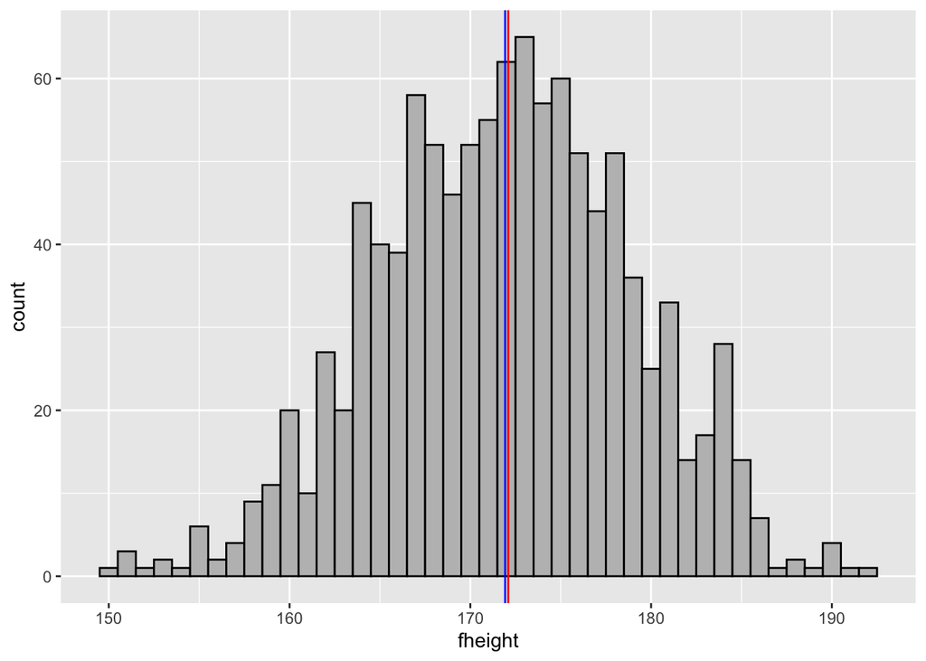

```r
ggplot(height, aes(x = fheight)) +
  geom_histogram(fill = "gray", col = "black", binwidth = 1) +
  geom_vline(xintercept = mean(height$fheight), color = "blue") +
  geom_vline(xintercept = median(height$fheight), color = "red")
```

#### 2.1.5

The distribution is pretty much normal and symmetric and the mean and median value are close to each other.

### 2.2 Financial transaction

#### 2.2.1

Transaction amount is a ratio scale variable as its zero value is meaningful. It is measured as continuous and non-negative quantity.

#### 2.2.2

```r
transaction <- read_delim("data/account-transactions.csv.bz2")
nrow(transaction)
```

```
## [1] 1657
```

```r
transaction %>%
 reframe(mean = mean(transaction$amount), median = median(transaction$amount), sd = sd(transaction$amount), range = range(transaction$amount))
```

```
## # A tibble: 2 × 4
##    mean median    sd   range
##   <dbl>  <dbl> <dbl>   <dbl>
## 1  89.9   11.9  368.    0.01
## 2  89.9   11.9  368. 4215
```

The mean of the transaction value is larger relatively larger than the median, meaning that it is is right-skewed distribution. The standard deviation is larger than the mean, indicating the transaction amount has a large range.

#### 2.2.3

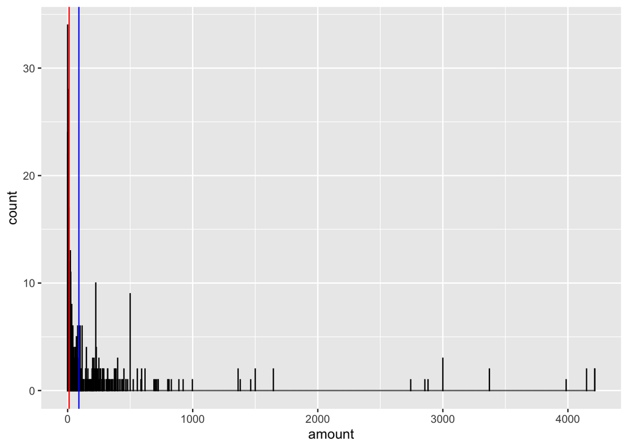

```r
ggplot(transaction, aes(amount)) +
  geom_histogram(fill = "gray", col = "black", binwidth = 0.1) +
  geom_vline(xintercept = mean(transaction$amount), color = "blue") +
  geom_vline(xintercept = median(transaction$amount), color = "red")
```

#### 2.2.4

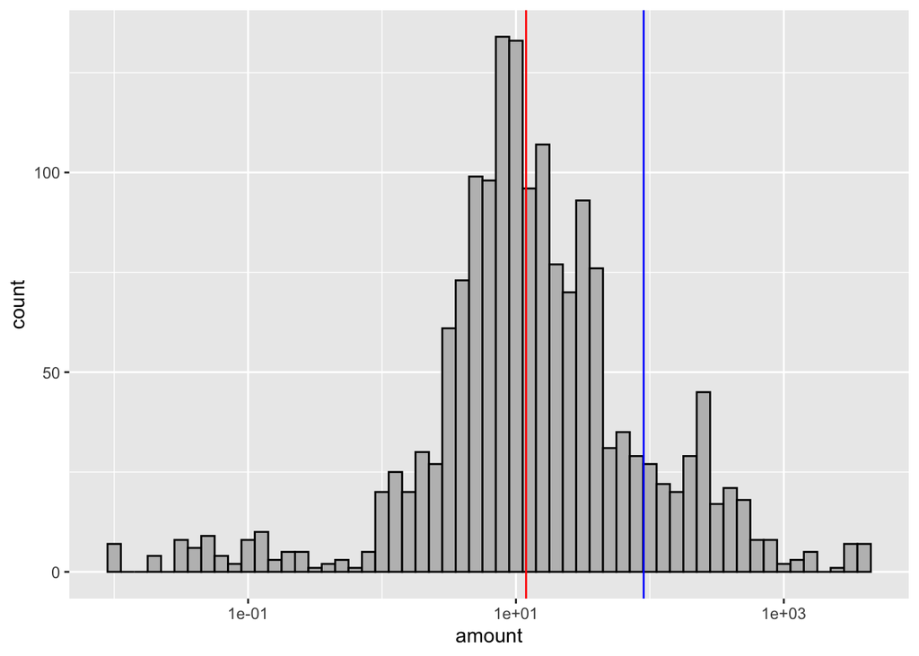

```r
ggplot(transaction, aes(amount)) +
  geom_histogram(fill = "gray", col = "black", binwidth = 0.1) +
  geom_vline(xintercept = mean(transaction$amount), color = "blue") +
  geom_vline(xintercept = median(transaction$amount), color = "red") +
  scale_x_log10()
```

#### 2.2.5

The first histogram without the log-scale has a strong right skew but after using the log-scale, the distribution becomes more symmetric and normal, meaning that the transaction amount has a log-normal distribution.

### 2.3 Human influence

#### 2.3.1

The number of citation is a ratio scale value and it is a discrete, non-negative variable.

#### 2.3.2

```r
citation <- read_delim("data/mag-30k-citations.csv.bz2")
nrow(citation)
```

```
## [1] 30000
```

```r
library(modeest)
mode <- modeest::mlv(citation$citations, method="mfv")
citation %>%
 reframe(mean = mean(citation$citations), median = median(citation$citations), sd = sd(citation$citations), range = range(citation$citations), mode)
```

```
## # A tibble: 2 × 5
##    mean median    sd range  mode
##   <dbl>  <dbl> <dbl> <dbl> <dbl>
## 1  15.6      2  79.2     0     0
## 2  15.6      2  79.2  7241     0
```

The mean value is much higher than the median, meaning that there is a right-skewed distribution. The standard deviation is much larger than the mean, hence the range of citation count is large. The mode indicates that the smaller citation counts is more common.

#### 2.3.3

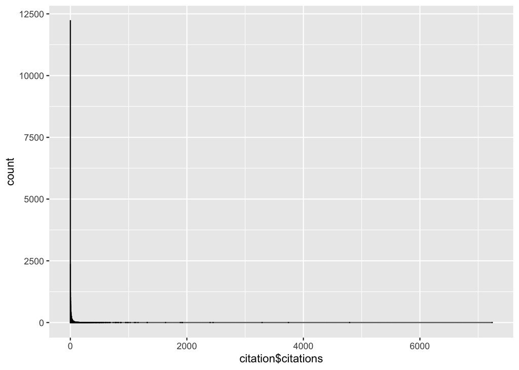

```r
ggplot(citation, aes(citation$citations)) +
  geom_histogram(fill = "gray", col = "black", binwidth = 1)
```

The histogram is hard to read, It shows a right skewed toward 0, has an extreme long tail, and has power law distribution.

#### 2.3.4

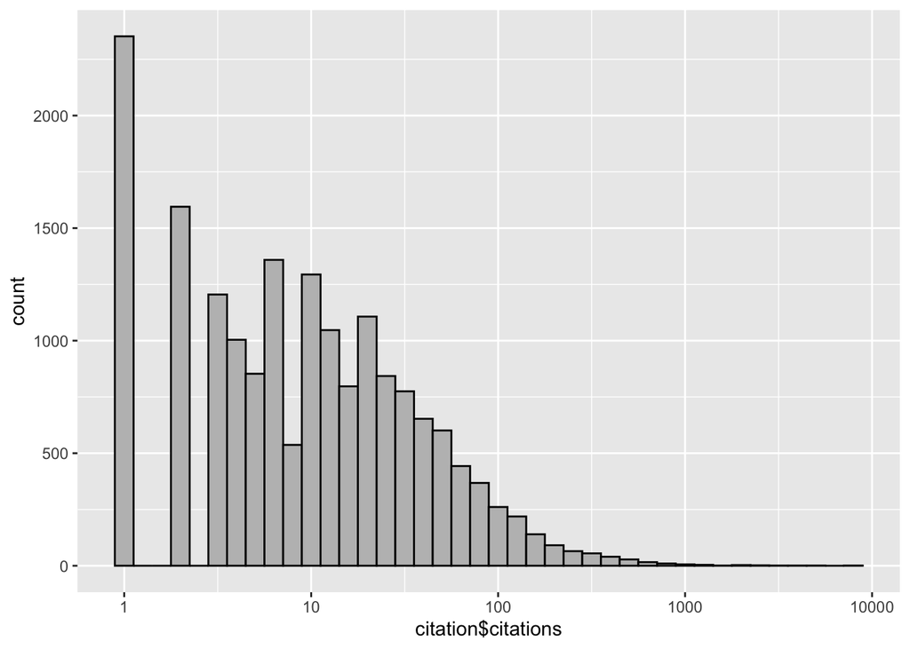

```r
ggplot(citation, aes(citation$citations)) +
  geom_histogram(fill = "gray", col = "black", binwidth = 0.1) +
  scale_x_log10()
```

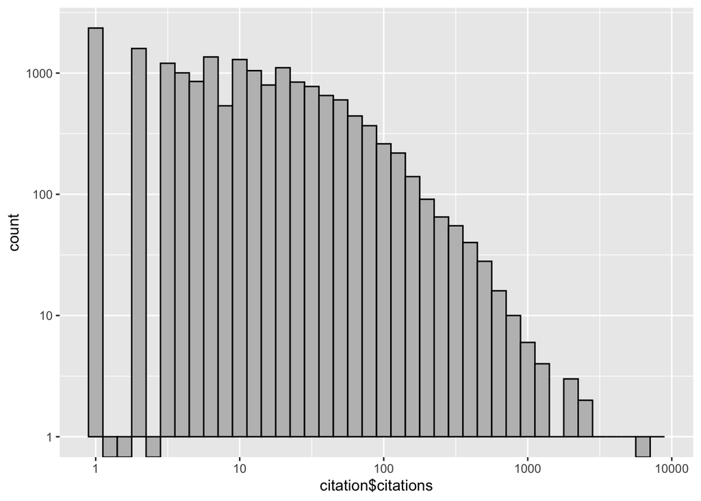

```r
ggplot(citation, aes(citation$citations)) +
  geom_histogram(fill = "gray", col = "black", binwidth = 0.1) +
  scale_x_log10() +
  scale_y_log10()
```

With the log scale, it is much easier to read and interpret the value. The histogram looks more linear, suggesting power law distribution of the data.

#### 2.3.5

human bodies: It is more normally distributed, as the data relates to biological condition and have more nature condition.

transaction: Has a strong right skewed at first and become normally distributed after using log-scale, suggesting a log-normal distribution. The data focuses more on economy condition.

influence: Also has a strong right skewed but becomes a linear like histogram after using log-scale and log-log scale, showing a power law distribution. The data focuses more on the influence

Overall, the result highlights the differences between the purpose of each data collection.

## 3 Functions of RV-s

### 3.1 Theoretical questions

#### 3.1.1

X = 0 p = 1/2 X = 1 p = 1/3 X = 2 p = 1/6

EX = 0 x 1/2 + 1 x 1/3 + 2 x 1/6 EX = 0 + 1/3 + 2/6 EX = 2/3

#### 3.1.2

EX^2 = 0^2 x 1/2 + 1^2 x 1/3 + 2^2 x 1/6 EX^2 = 0 + 1/3 + 4/6 EX^2 = 1

For a discrete RV, E[f(x)] = sum of f(x) x p(X = x). In this question f(x) = x^2, hence squared each x value and multiple it by the probability and add all together.

#### 3.1.3

VarX = EX^2 - (EX)^2 VarX = 1 - (2/3)^2 VarX = 1 - 4/9 VarX = 5/9

#### 3.1.4

Var3X = 3^2 x VarX Var3X = 9 x 5/9 Var3x = 5

### 3.2 Simulation

#### 3.2.1

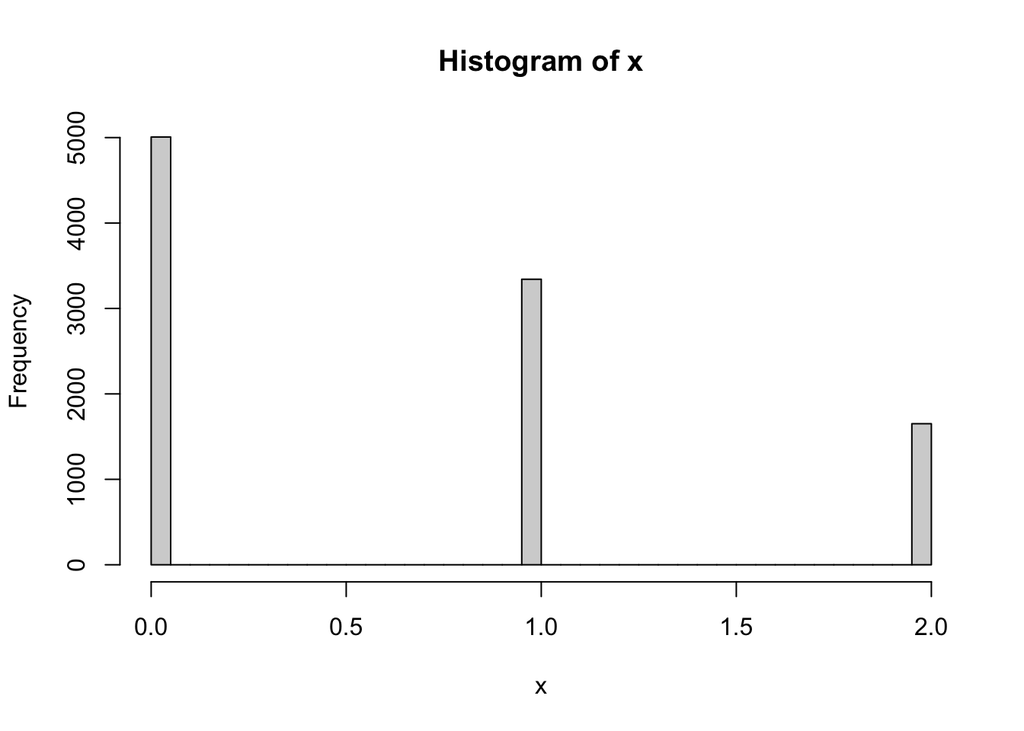

```r
x <- sample(c(0, 1, 2), 10000, replace = TRUE, prob = c(1/2, 1/3, 1/6))
hist(x, breaks = seq(0, 2, by = 0.05))
```

#### 3.2.2

```r
mean(x)
```

```
## [1] 0.6644
```

```r
mean(x^2)
```

```
## [1] 0.9946
```

```r
var(x)
```

```
## [1] 0.553228
```

```r
mean(3*x)
```

```
## [1] 1.9932
```

```r
var(3*x)
```

```
## [1] 4.979052
```

Yes, the values are close.

#### How much time did you spend on this PS?

around 7 hours